# RAB117_report

Marion Hardy

2023-05-12

# Introduction

Analyse d’un screening CRISPR dans des cellules tryptophane neg. Raphaële a fourni un fichier word détaillé qui explique la manip et les algorithmes utilisés.

Il y a trois fichiers MLE et trois RRA (triplicats biologiques) qui contiennent chacun un b score = une moyenne, un z score = un score qui prend en compte la moyenne et la déviation standard et des pval + wald tests + fdr.

Je vais pool les trois fichiers, avoir le score z des triplicats et déterminer les outliers puis les comparer à ceux que Raphaële a (pour contrôler que je fais pas du caca). Ensuite je prendrai les outliers recroisés entre le MLE et RRA pour pouvoir produire les différentes figures dont Raphaële a besoin.

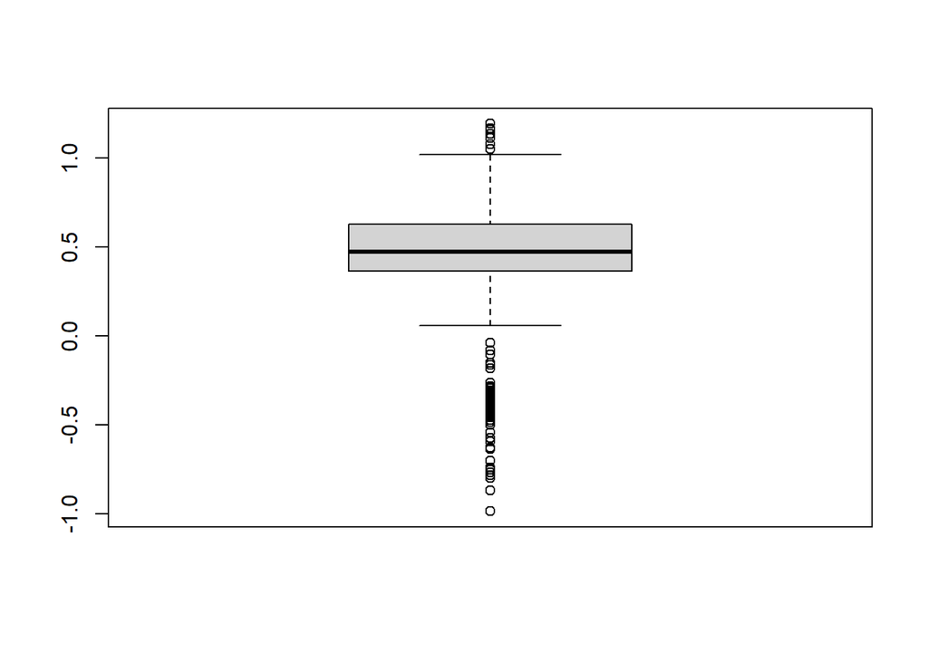

```r
files = list.files("./data/", pattern = "*mle_trp*")

for (i in 1:length(files)){
  file = read_xlsx(paste0("./data/",files[i]))
  file = file %>% filter(sgRNA >=4) %>%
    dplyr::select(Gene, `treatment|beta`,`treatment|p-value`)
  colnames(file) = c("Gene", paste0("mean_",i), paste0("pval_",i))
  assign(paste0("mle_",i), file)
}

data = list(mle_1, mle_2, mle_3) %>%
  purrr::reduce(full_join)

data_all =
  data %>%
  drop_na() %>%
  rowwise() %>%
  mutate(mean = mean(c(mean_1, mean_2, mean_3)),
         sd = sd(c(mean_1, mean_2, mean_3)),
         pval = mean(c(pval_1, pval_2, pval_3))) %>%
  dplyr::select(Gene, mean, sd, pval)

data =
  data_all %>%
    filter(pval<= 0.05)

boxplot(data$mean)
```

```r
median(data$mean)
```

```
## [1] 0.4738267
```

```r
outliers =
  data %>%
  filter(mean < quantile(data$mean)[2]|mean > quantile(data$mean)[4])

down =
  data %>%
  filter(mean < -0.3)

outliers %>%
  head(15) %>%
  knitr::kable()
```

| Gene | mean | sd | pval |
| --- | --- | --- | --- |
| Mrpl28 | 1.1918667 | 0.1163599 | 0.0000000 |
| Ndufa1 | 1.1643667 | 0.0969317 | 0.0000181 |
| 37316 | 1.0765400 | 0.1310024 | 0.0000000 |
| Mrpl20 | 1.1647333 | 0.0715976 | 0.0000000 |
| Ndufa2 | 1.1362333 | 0.0476430 | 0.0000000 |
| Ptplb | 0.9026700 | 0.3572377 | 0.0004527 |
| Mrps25 | 1.1595667 | 0.1321792 | 0.0000000 |
| Agpat1 | 1.0188100 | 0.1424605 | 0.0000181 |
| Hsd17b10 | 0.9095200 | 0.1850416 | 0.0000362 |
| Ndufc2 | 1.1130333 | 0.0349172 | 0.0000000 |
| Gnb2l1 | 1.0756667 | 0.0651772 | 0.0000000 |
| Mrpl41 | 0.9315833 | 0.1756950 | 0.0000181 |
| Dbr1 | 0.9692067 | 0.1070501 | 0.0000181 |
| Tufm | 0.8323300 | 0.2199795 | 0.0000543 |
| Ncl | 0.6533667 | 0.3726756 | 0.0087642 |

```r
dim(outliers)
```

```
## [1] 288   4
```

Quand je filtre pour pval < 0.05, j’ai 288 outliers pour les MLE compparé aux 261 de Raphaële. On va partir de la liste des outliers MLE+RRA qu’elle a fournie pour la suite.

# Possible plots

## MLE : pval and mean

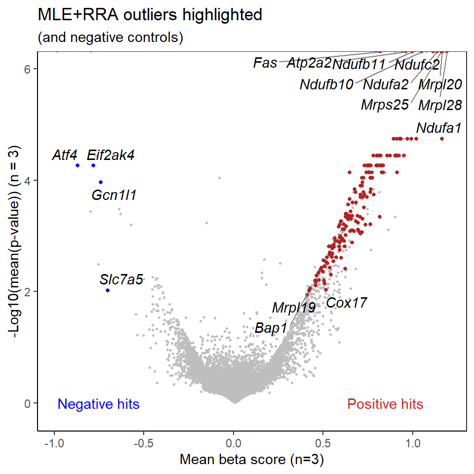

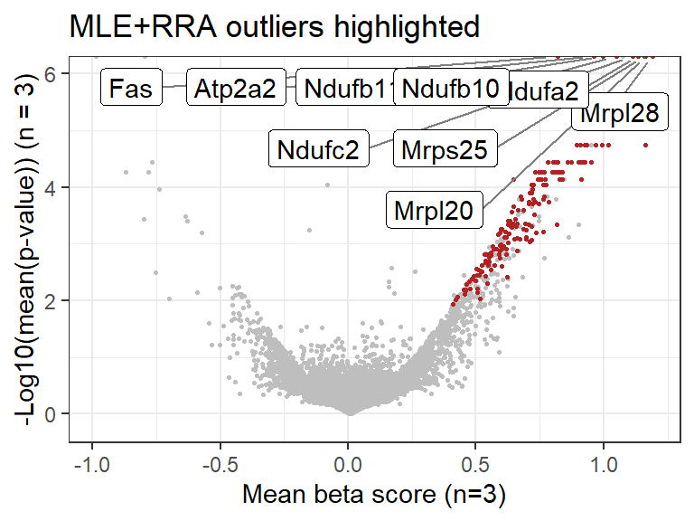

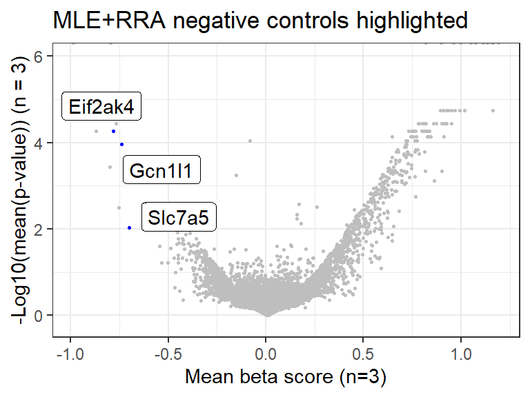

## RRA : pval and mean

Il faudrait retrouver les fichiers avec les pvaleurs

## Number of gene attributed at random

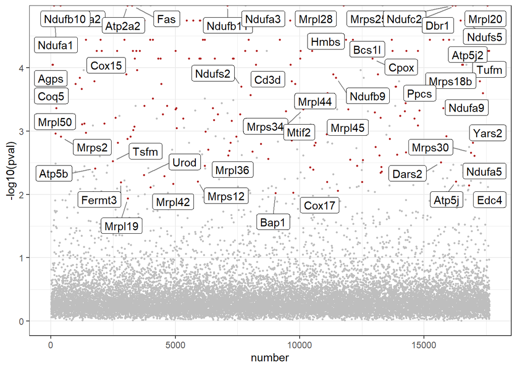

## Number of gene attributed not at random

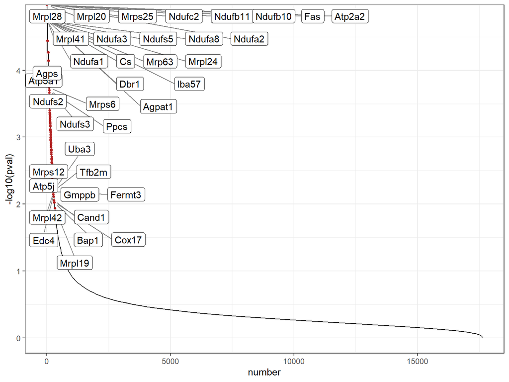

# ORA

## Gene ontology

### On the 577 significant genes (not specifically the outliers)

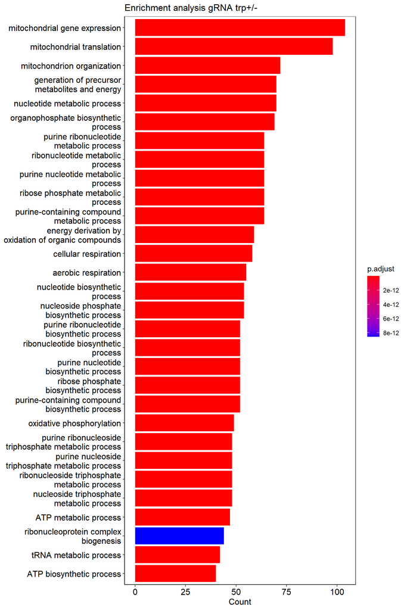

| ID | Description | GeneRatio | BgRatio | pvalue | p.adjust |
| --- | --- | --- | --- | --- | --- |
| GO:0032543 | mitochondrial translation | 98/540 | 124/15834 | 0 | 0 |
| GO:0140053 | mitochondrial gene expression | 104/540 | 149/15834 | 0 | 0 |
| GO:0042776 | proton motive force-driven mitochondrial ATP synthesis | 39/540 | 50/15834 | 0 | 0 |
| GO:0015986 | proton motive force-driven ATP synthesis | 39/540 | 53/15834 | 0 | 0 |
| GO:0006119 | oxidative phosphorylation | 49/540 | 105/15834 | 0 | 0 |
| GO:0009060 | aerobic respiration | 55/540 | 147/15834 | 0 | 0 |
| GO:0010257 | NADH dehydrogenase complex assembly | 35/540 | 47/15834 | 0 | 0 |
| GO:0032981 | mitochondrial respiratory chain complex I assembly | 35/540 | 47/15834 | 0 | 0 |
| GO:0045333 | cellular respiration | 58/540 | 197/15834 | 0 | 0 |
| GO:0033108 | mitochondrial respiratory chain complex assembly | 39/540 | 73/15834 | 0 | 0 |

### On the 177 positive outliers

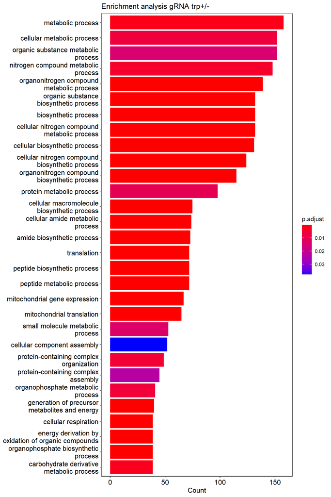

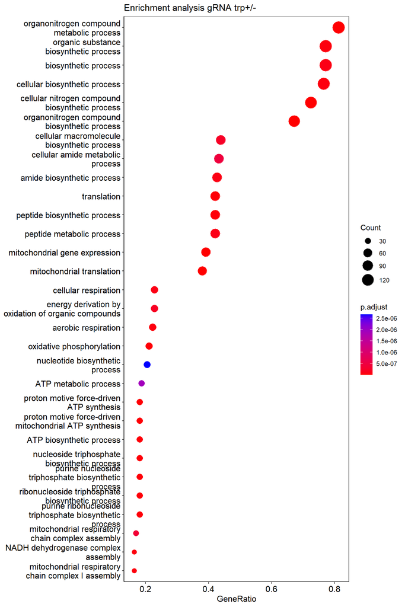

| ONTOLOGY | ID | Description | GeneRatio | BgRatio | pvalue |
| --- | --- | --- | --- | --- | --- |
| BP | GO:1901566 | organonitrogen compound biosynthetic process | 115/171 | 215/540 | 0 |
| BP | GO:0032543 | mitochondrial translation | 65/171 | 98/540 | 0 |
| BP | GO:0140053 | mitochondrial gene expression | 67/171 | 104/540 | 0 |
| BP | GO:0044271 | cellular nitrogen compound biosynthetic process | 124/171 | 280/540 | 0 |
| BP | GO:1901564 | organonitrogen compound metabolic process | 139/171 | 334/540 | 0 |
| BP | GO:0015986 | proton motive force-driven ATP synthesis | 31/171 | 39/540 | 0 |
| BP | GO:0042776 | proton motive force-driven mitochondrial ATP synthesis | 31/171 | 39/540 | 0 |
| BP | GO:0006119 | oxidative phosphorylation | 36/171 | 49/540 | 0 |
| BP | GO:0006412 | translation | 72/171 | 134/540 | 0 |
| BP | GO:0006754 | ATP biosynthetic process | 31/171 | 40/540 | 0 |

### On the 144 negative outliers

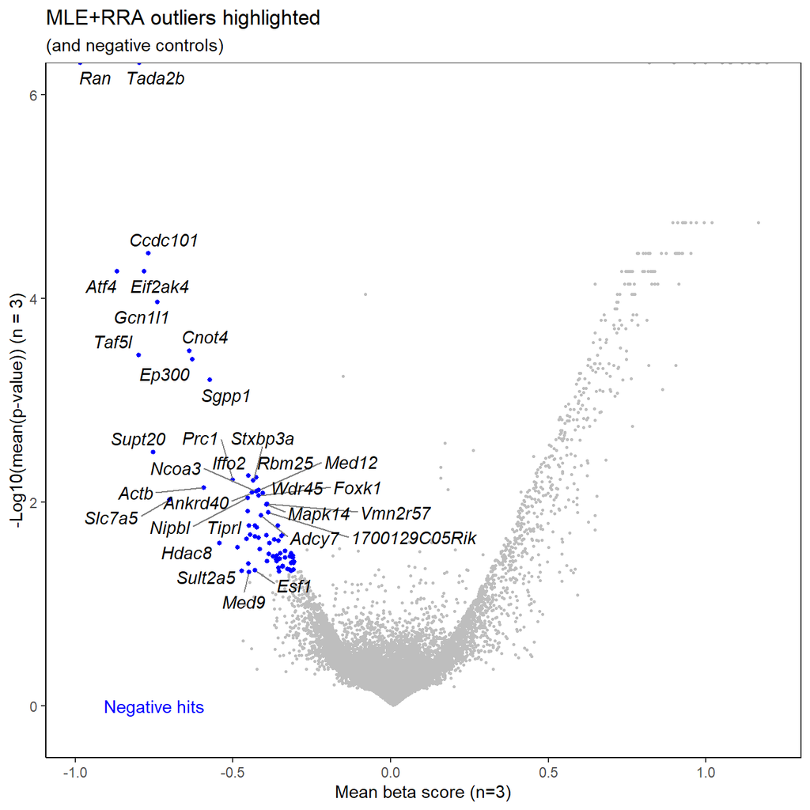

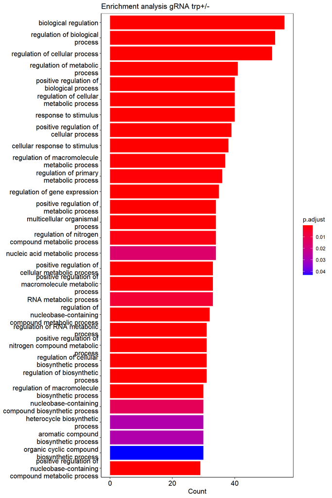

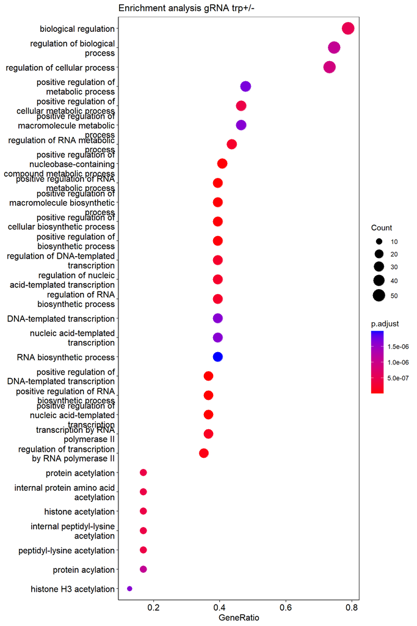

| ONTOLOGY | ID | Description | GeneRatio | BgRatio | pvalue |
| --- | --- | --- | --- | --- | --- |
| BP | GO:0045893 | positive regulation of DNA-templated transcription | 26/71 | 53/540 | 0 |
| BP | GO:1902680 | positive regulation of RNA biosynthetic process | 26/71 | 53/540 | 0 |
| BP | GO:1903508 | positive regulation of nucleic acid-templated transcription | 26/71 | 53/540 | 0 |
| BP | GO:0051254 | positive regulation of RNA metabolic process | 28/71 | 64/540 | 0 |
| BP | GO:0010557 | positive regulation of macromolecule biosynthetic process | 28/71 | 67/540 | 0 |
| BP | GO:0045935 | positive regulation of nucleobase-containing compound metabolic process | 29/71 | 72/540 | 0 |
| BP | GO:0031328 | positive regulation of cellular biosynthetic process | 28/71 | 68/540 | 0 |
| BP | GO:0009891 | positive regulation of biosynthetic process | 28/71 | 69/540 | 0 |
| BP | GO:0006357 | regulation of transcription by RNA polymerase II | 25/71 | 58/540 | 0 |
| BP | GO:0006366 | transcription by RNA polymerase II | 26/71 | 64/540 | 0 |

## Reactome

### On the 577 significant genes (not specifically the outliers)

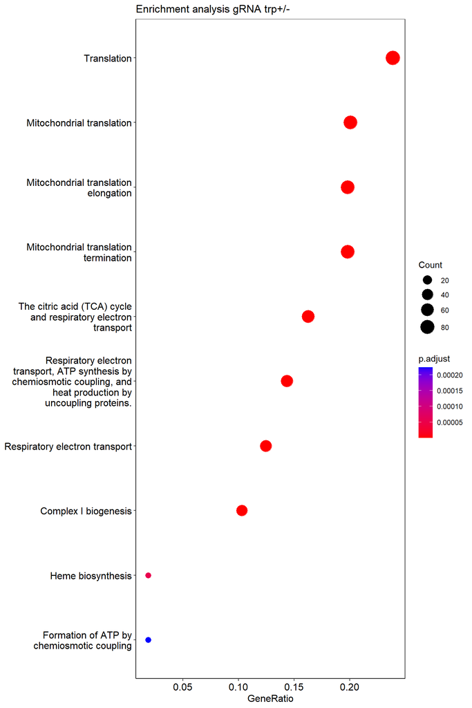

| ID | Description | GeneRatio | BgRatio | pvalue | p.adjust |
| --- | --- | --- | --- | --- | --- |
| R-MMU-5389840 | Mitochondrial translation elongation | 73/369 | 83/8501 | 0.0e+00 | 0.0000000 |
| R-MMU-5368287 | Mitochondrial translation | 74/369 | 86/8501 | 0.0e+00 | 0.0000000 |
| R-MMU-5419276 | Mitochondrial translation termination | 73/369 | 85/8501 | 0.0e+00 | 0.0000000 |
| R-MMU-72766 | Translation | 88/369 | 220/8501 | 0.0e+00 | 0.0000000 |
| R-MMU-163200 | Respiratory electron transport, ATP synthesis by chemiosmotic coupling, and heat production by uncoupling proteins. | 53/369 | 116/8501 | 0.0e+00 | 0.0000000 |
| R-MMU-1428517 | The citric acid (TCA) cycle and respiratory electron transport | 60/369 | 163/8501 | 0.0e+00 | 0.0000000 |
| R-MMU-6799198 | Complex I biogenesis | 38/369 | 55/8501 | 0.0e+00 | 0.0000000 |
| R-MMU-611105 | Respiratory electron transport | 46/369 | 93/8501 | 0.0e+00 | 0.0000000 |
| R-MMU-189451 | Heme biosynthesis | 7/369 | 14/8501 | 7.0e-07 | 0.0000541 |
| R-MMU-163210 | Formation of ATP by chemiosmotic coupling | 7/369 | 17/8501 | 3.7e-06 | 0.0002238 |

### On the positive 177 outliers

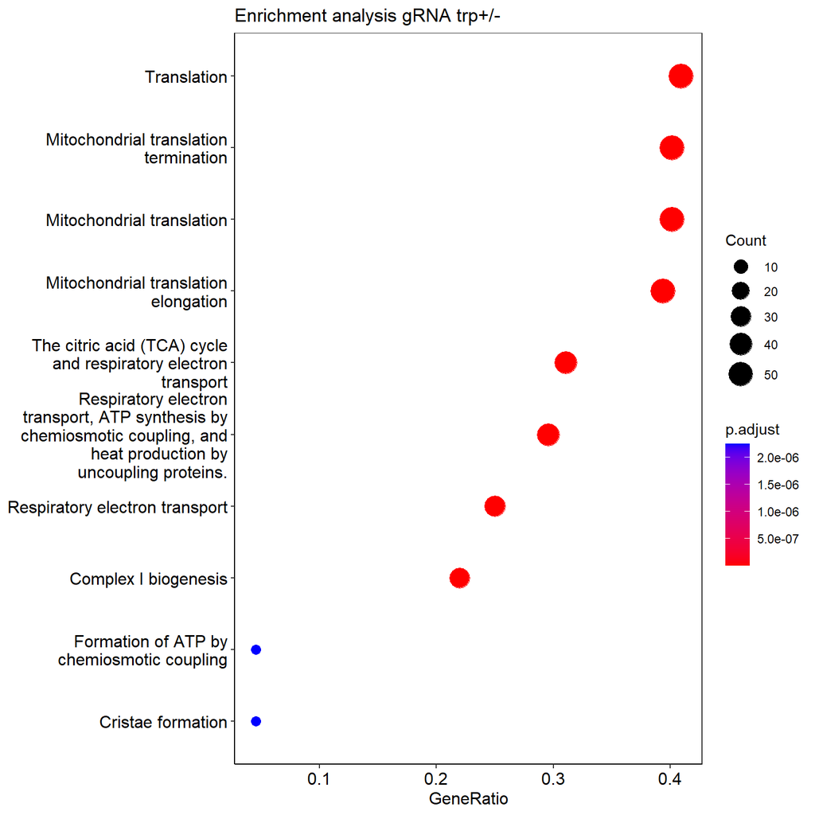

| ID | Description | GeneRatio | BgRatio | pvalue | p.adjust |
| --- | --- | --- | --- | --- | --- |
| R-MMU-5419276 | Mitochondrial translation termination | 53/132 | 85/8501 | 0e+00 | 0.0e+00 |
| R-MMU-5368287 | Mitochondrial translation | 53/132 | 86/8501 | 0e+00 | 0.0e+00 |
| R-MMU-5389840 | Mitochondrial translation elongation | 52/132 | 83/8501 | 0e+00 | 0.0e+00 |
| R-MMU-72766 | Translation | 54/132 | 220/8501 | 0e+00 | 0.0e+00 |
| R-MMU-163200 | Respiratory electron transport, ATP synthesis by chemiosmotic coupling, and heat production by uncoupling proteins. | 39/132 | 116/8501 | 0e+00 | 0.0e+00 |
| R-MMU-1428517 | The citric acid (TCA) cycle and respiratory electron transport | 41/132 | 163/8501 | 0e+00 | 0.0e+00 |
| R-MMU-6799198 | Complex I biogenesis | 29/132 | 55/8501 | 0e+00 | 0.0e+00 |
| R-MMU-611105 | Respiratory electron transport | 33/132 | 93/8501 | 0e+00 | 0.0e+00 |
| R-MMU-163210 | Formation of ATP by chemiosmotic coupling | 6/132 | 17/8501 | 1e-07 | 2.2e-06 |
| R-MMU-8949613 | Cristae formation | 6/132 | 17/8501 | 1e-07 | 2.2e-06 |

### On the negative 144 outliers

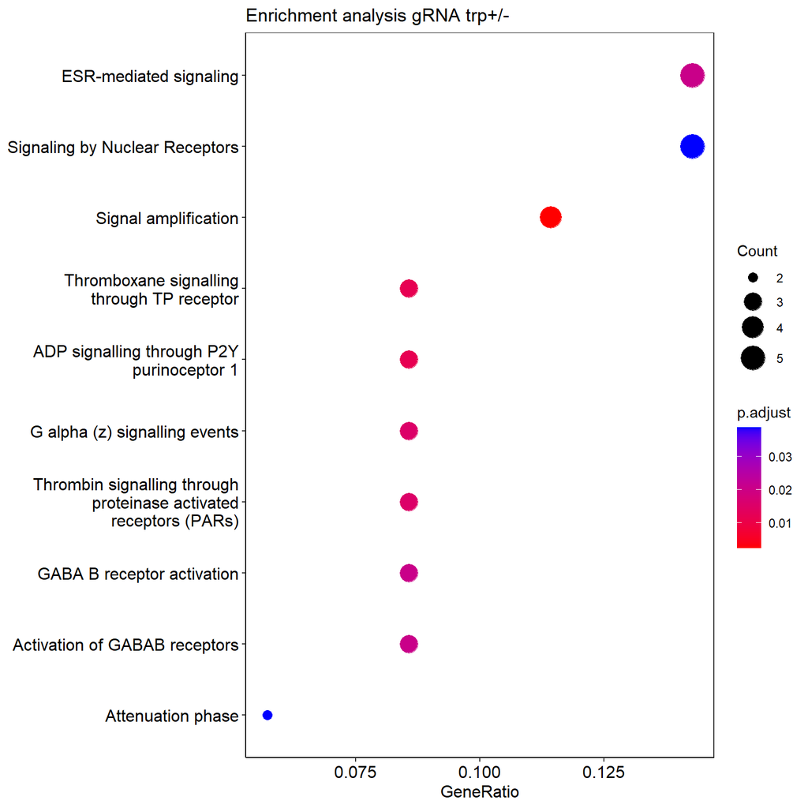

| ID | Description | GeneRatio | BgRatio | pvalue | p.adjust |
| --- | --- | --- | --- | --- | --- |
| R-MMU-392518 | Signal amplification | 4/35 | 32/8501 | 0.0000080 | 0.0023218 |
| R-MMU-428930 | Thromboxane signalling through TP receptor | 3/35 | 23/8501 | 0.0001070 | 0.0118309 |
| R-MMU-418592 | ADP signalling through P2Y purinoceptor 1 | 3/35 | 24/8501 | 0.0001220 | 0.0118309 |
| R-MMU-418597 | G alpha (z) signalling events | 3/35 | 31/8501 | 0.0002656 | 0.0154565 |
| R-MMU-456926 | Thrombin signalling through proteinase activated receptors (PARs) | 3/35 | 31/8501 | 0.0002656 | 0.0154565 |
| R-MMU-8939211 | ESR-mediated signaling | 5/35 | 158/8501 | 0.0004306 | 0.0207013 |
| R-MMU-977444 | GABA B receptor activation | 3/35 | 40/8501 | 0.0005691 | 0.0207013 |
| R-MMU-991365 | Activation of GABAB receptors | 3/35 | 40/8501 | 0.0005691 | 0.0207013 |
| R-MMU-3371568 | Attenuation phase | 2/35 | 13/8501 | 0.0012485 | 0.0389347 |
| R-MMU-9006931 | Signaling by Nuclear Receptors | 5/35 | 208/8501 | 0.0014919 | 0.0389347 |

# Highlight genes per found role

## Outliers found in GO terms (BP and CC)

| ONTOLOGY | ID | Description | GeneRatio | BgRatio | pvalue |
| --- | --- | --- | --- | --- | --- |
| BP | GO:1901566 | organonitrogen compound biosynthetic process | 115/171 | 215/540 | 0e+00 |
| BP | GO:0032543 | mitochondrial translation | 65/171 | 98/540 | 0e+00 |
| BP | GO:0140053 | mitochondrial gene expression | 67/171 | 104/540 | 0e+00 |
| BP | GO:0044271 | cellular nitrogen compound biosynthetic process | 124/171 | 280/540 | 0e+00 |
| BP | GO:1901564 | organonitrogen compound metabolic process | 139/171 | 334/540 | 0e+00 |
| BP | GO:0015986 | proton motive force-driven ATP synthesis | 31/171 | 39/540 | 0e+00 |
| BP | GO:0042776 | proton motive force-driven mitochondrial ATP synthesis | 31/171 | 39/540 | 0e+00 |
| BP | GO:0006119 | oxidative phosphorylation | 36/171 | 49/540 | 0e+00 |
| BP | GO:0006412 | translation | 72/171 | 134/540 | 0e+00 |
| BP | GO:0006754 | ATP biosynthetic process | 31/171 | 40/540 | 0e+00 |
| BP | GO:0009142 | nucleoside triphosphate biosynthetic process | 31/171 | 40/540 | 0e+00 |
| BP | GO:0009145 | purine nucleoside triphosphate biosynthetic process | 31/171 | 40/540 | 0e+00 |
| BP | GO:0009201 | ribonucleoside triphosphate biosynthetic process | 31/171 | 40/540 | 0e+00 |
| BP | GO:0009206 | purine ribonucleoside triphosphate biosynthetic process | 31/171 | 40/540 | 0e+00 |
| BP | GO:0043043 | peptide biosynthetic process | 72/171 | 135/540 | 0e+00 |
| BP | GO:0010257 | NADH dehydrogenase complex assembly | 28/171 | 35/540 | 0e+00 |
| BP | GO:0032981 | mitochondrial respiratory chain complex I assembly | 28/171 | 35/540 | 0e+00 |
| BP | GO:1901576 | organic substance biosynthetic process | 132/171 | 318/540 | 0e+00 |
| BP | GO:0009060 | aerobic respiration | 38/171 | 55/540 | 0e+00 |
| BP | GO:0044249 | cellular biosynthetic process | 131/171 | 315/540 | 0e+00 |
| BP | GO:0043604 | amide biosynthetic process | 73/171 | 140/540 | 0e+00 |
| BP | GO:0009058 | biosynthetic process | 132/171 | 320/540 | 0e+00 |
| BP | GO:0045333 | cellular respiration | 39/171 | 58/540 | 0e+00 |
| BP | GO:0006518 | peptide metabolic process | 72/171 | 138/540 | 0e+00 |
| BP | GO:0015980 | energy derivation by oxidation of organic compounds | 39/171 | 59/540 | 0e+00 |
| BP | GO:0034645 | cellular macromolecule biosynthetic process | 75/171 | 148/540 | 0e+00 |
| BP | GO:0033108 | mitochondrial respiratory chain complex assembly | 29/171 | 39/540 | 0e+00 |
| BP | GO:0043603 | cellular amide metabolic process | 74/171 | 147/540 | 0e+00 |
| BP | GO:0046034 | ATP metabolic process | 32/171 | 47/540 | 1e-07 |
| BP | GO:0009165 | nucleotide biosynthetic process | 35/171 | 54/540 | 1e-07 |

Organize by theme

- BP Mitochondrial gene expression (encompasses mitochondrial translation)
- BP ATP metabolic process (encompasses proton-motive force driven ATP prod)
- CC respiratory chain complex I
- BP oxidative phosphorylation

## Outliers found in reactome

| ID | Description | GeneRatio | BgRatio |
| --- | --- | --- | --- |
| R-MMU-5419276 | Mitochondrial translation termination | 53/132 | 85/8501 |
| R-MMU-5368287 | Mitochondrial translation | 53/132 | 86/8501 |
| R-MMU-5389840 | Mitochondrial translation elongation | 52/132 | 83/8501 |
| R-MMU-72766 | Translation | 54/132 | 220/8501 |
| R-MMU-163200 | Respiratory electron transport, ATP synthesis by chemiosmotic coupling, and heat production by uncoupling proteins. | 39/132 | 116/8501 |
| R-MMU-1428517 | The citric acid (TCA) cycle and respiratory electron transport | 41/132 | 163/8501 |
| R-MMU-6799198 | Complex I biogenesis | 29/132 | 55/8501 |
| R-MMU-611105 | Respiratory electron transport | 33/132 | 93/8501 |
| R-MMU-163210 | Formation of ATP by chemiosmotic coupling | 6/132 | 17/8501 |
| R-MMU-8949613 | Cristae formation | 6/132 | 17/8501 |
| R-MMU-189451 | Heme biosynthesis | 5/132 | 14/8501 |
| R-MMU-1592230 | Mitochondrial biogenesis | 6/132 | 27/8501 |
| R-MMU-189445 | Metabolism of porphyrins | 5/132 | 31/8501 |
| R-MMU-3371378 | Regulation by c-FLIP | 2/132 | 10/8501 |
| R-MMU-5218900 | CASP8 activity is inhibited | 2/132 | 10/8501 |
| R-MMU-69416 | Dimerization of procaspase-8 | 2/132 | 10/8501 |
| R-MMU-1362409 | Mitochondrial iron-sulfur cluster biogenesis | 2/132 | 11/8501 |
| R-MMU-202427 | Phosphorylation of CD3 and TCR zeta chains | 2/132 | 12/8501 |
| R-MMU-199220 | Vitamin B5 (pantothenate) metabolism | 2/132 | 13/8501 |
| R-MMU-389948 | PD-1 signaling | 2/132 | 13/8501 |
| R-MMU-140534 | Caspase activation via Death Receptors in the presence of ligand | 2/132 | 15/8501 |
| R-MMU-202433 | Generation of second messenger molecules | 2/132 | 19/8501 |
| R-MMU-5357769 | Caspase activation via extrinsic apoptotic signalling pathway | 2/132 | 19/8501 |
| R-MMU-71403 | Citric acid cycle (TCA cycle) | 2/132 | 21/8501 |
| R-MMU-5213460 | RIPK1-mediated regulated necrosis | 2/132 | 28/8501 |
| R-MMU-5675482 | Regulation of necroptotic cell death | 2/132 | 28/8501 |
| R-MMU-1852241 | Organelle biogenesis and maintenance | 6/132 | 212/8501 |
| R-MMU-9706019 | RHOBTB3 ATPase cycle | 1/132 | 10/8501 |
| R-MMU-264870 | Caspase-mediated cleavage of cytoskeletal proteins | 1/132 | 11/8501 |
| R-MMU-71406 | Pyruvate metabolism and Citric Acid (TCA) cycle | 2/132 | 47/8501 |

Organize by theme

- Mitochondrial translation
- The citric acid (TCA) cycle and respiratory electron transport
- Complex I biogenesis